# Homework 2: PCA for Image Compression

Saisarath Bolneni

# Introduction

For this project, I compress four photos using principal component analysis (PCA). The objective is to determine how effectively each image can be recreated with just the initial principle components. A smaller value of $k$ gives more compression, while a larger value of $k$ keeps more information from the original image.

# Read in the images

```r
image1 <- read_csv("/Users/saisarathb/SDS365/homework2/HW2imagefiles/image1.csv")
image2 <- read_csv("/Users/saisarathb/SDS365/homework2/HW2imagefiles/image2.csv")
image3 <- read_csv("/Users/saisarathb/SDS365/homework2/HW2imagefiles/image3.csv")
image4 <- read_csv("/Users/saisarathb/SDS365/homework2/HW2imagefiles/image4.csv")

# Convert each data frame into a matrix
image1 <- data.matrix(image1)
image2 <- data.matrix(image2)
image3 <- data.matrix(image3)
image4 <- data.matrix(image4)
```

# Image compression function

```r
compress_image <- function(x, k) {

  # Step 1: Calculate V = X'X
  V <- t(x) %*% x

  # Step 2: Find the eigenvalues and eigenvectors of V
  eig <- eigen(V)
  U <- eig$vectors

  # Step 3: Calculate the principal component scores Z = XU
  Z <- x %*% U

  # Step 4: Keep only the first k eigenvectors and PC scores
  U_k <- U[, 1:k, drop = FALSE]
  Z_k <- Z[, 1:k, drop = FALSE]

  # Step 5: Create the rank-k approximation
  x_k <- Z_k %*% t(U_k)

  # Step 6: Calculate the Frobenius norm error
  error <- norm(x - x_k, type = "F")

  # Step 7: Return the approximation and error
  return(list(
    approximation = x_k,
    error = error
  ))
}
```

# Image 1

## Original and first 10 PCA approximations

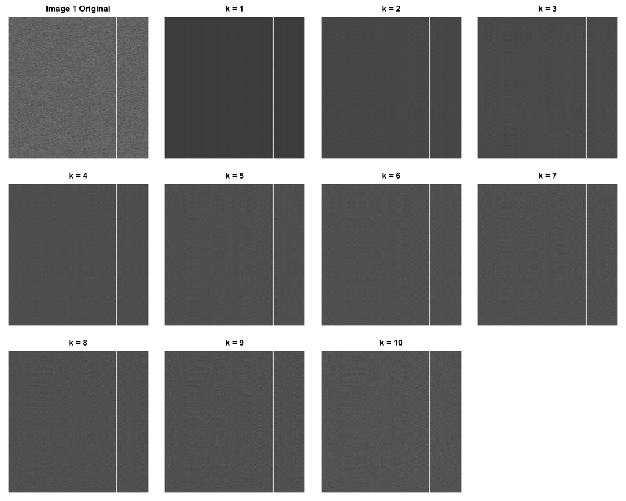

The main feature of Image 1 is the bright vertical line. It shows up clearly even in the first PCA approximation. As $k$ increases, more of the background variation comes back, but the main structure does not change very much.

## Approximation error

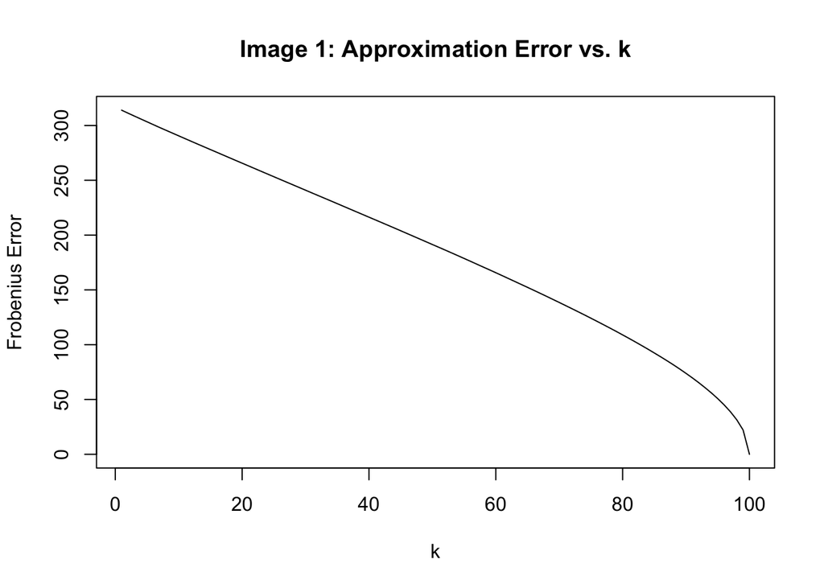

The error decreases as more principal components are included. The first component captures the strongest visual feature, but there is still background noise that takes many more components to reproduce.

## First eigenvector and first PC score

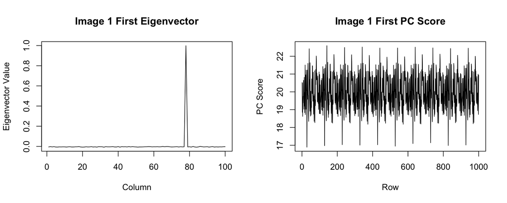

Interpretation: The first eigenvector shows the strongest pattern across the columns of the image. The large feature in this vector is connected to the bright vertical line in the image. The first PC score shows how strongly that pattern appears across each row. Since the vertical line continues through most of the image, the first score keeps that feature strong across many rows.

## My choice of k

I would use **k = 1** for Image 1 if the goal is to keep the main visual feature with as much compression as possible. The bright line is already very clear at this point, and larger values of $k$ mostly bring back the noisy background.

# Image 2

## Original and first 10 PCA approximations

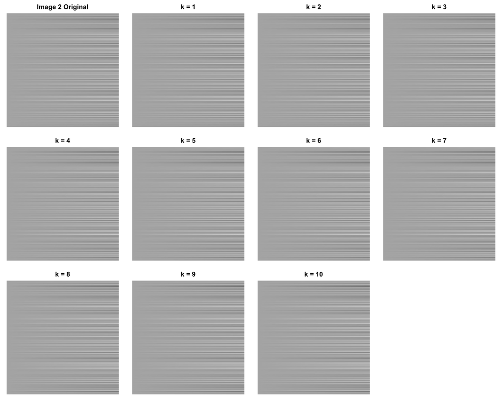

Image 2 is much simpler than the other images. Its horizontal pattern is recovered almost immediately. By $k = 2$, the approximation looks essentially the same as the original image.

## Approximation error

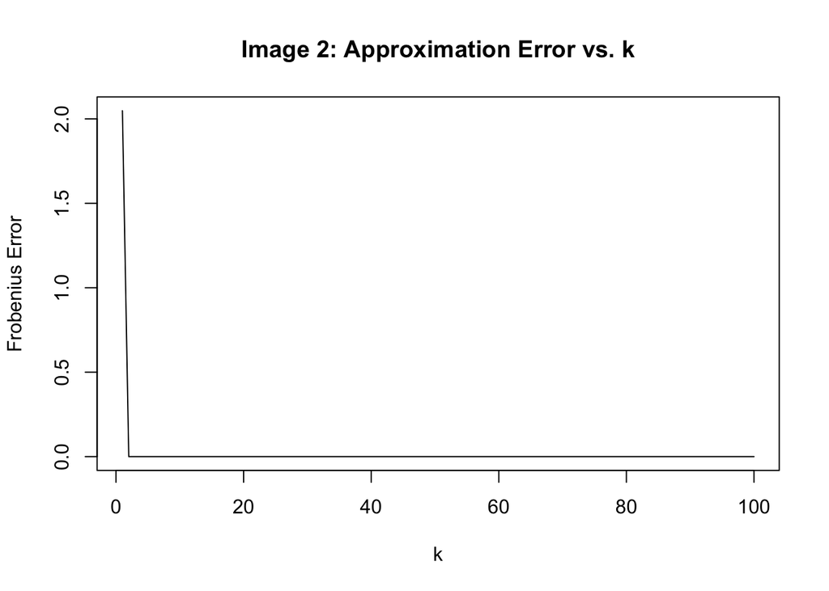

The error becomes almost zero by $k = 2$. This means almost all of the information in Image 2 can be represented using only two principal components.

## First eigenvector and first PC score

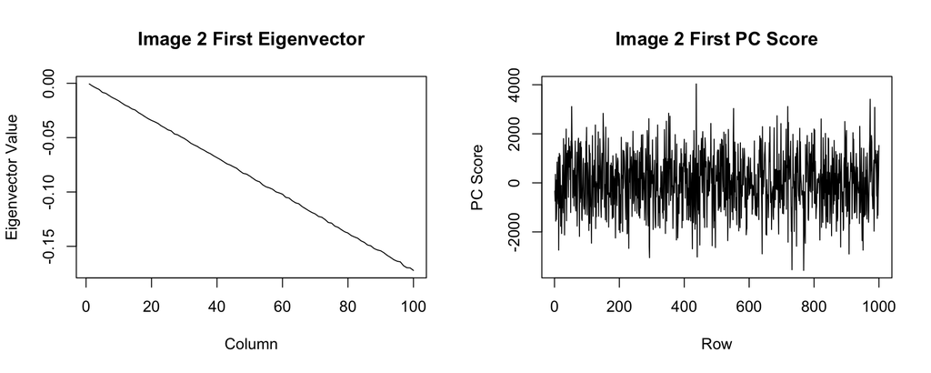

The first eigenvector shows the main pattern across the columns. The first PC score shows how the strength of that pattern changes across the rows. Since the image mainly changes in horizontal bands, only a very small number of components are needed to describe most of it.

## My choice of k

I would choose **k = 2** for Image 2. The approximation is already essentially identical to the original, so using more components would not give a meaningful visual improvement.

# Image 3

## Original and first 10 PCA approximations

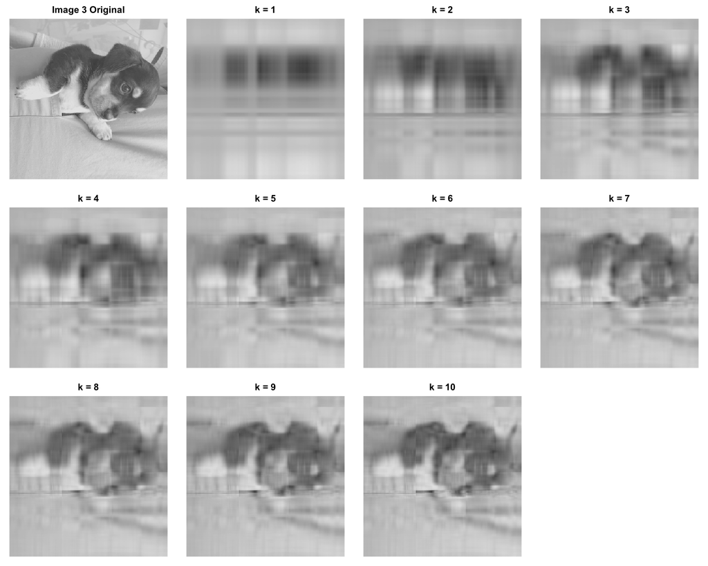

Image 3 is a real photograph, so it has much more detail than Images 1 and 2. With a very small value of $k$, the overall shape of the puppy is visible, but the image is blurry. As $k$ increases, the face, body, and background become easier to distinguish.

## Approximation error

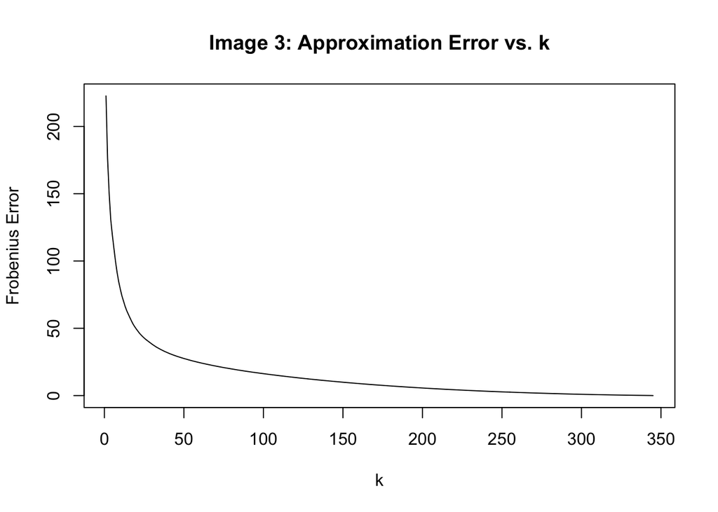

The error drops quickly at first and then decreases more gradually. This tells me that the first few components capture the main structure of the photograph, while later components mainly add smaller details.

## First eigenvector and first PC score

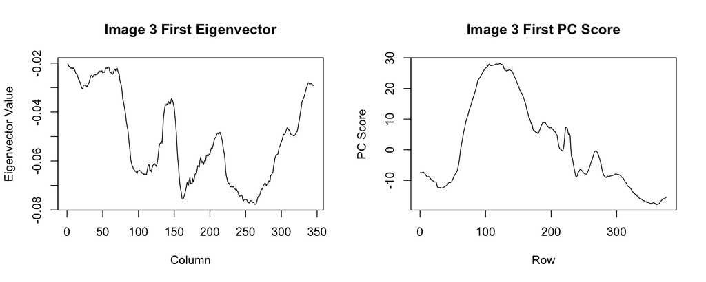

The first eigenvector represents the strongest overall pattern across the columns of the photo, especially broad differences in brightness and contrast. The first PC score shows how strongly that pattern appears across the rows. Together, they capture the largest overall structure of the puppy and the background before the smaller details are added by later components.

## My choice of k

I would choose about **k = 20** for Image 3. At that point, the puppy is clearly recognizable and the important parts of the photo are visible. Higher values improve the smaller details, but the change is less dramatic than it is for the first 20 components.

# Image 4

## Original and first 10 PCA approximations

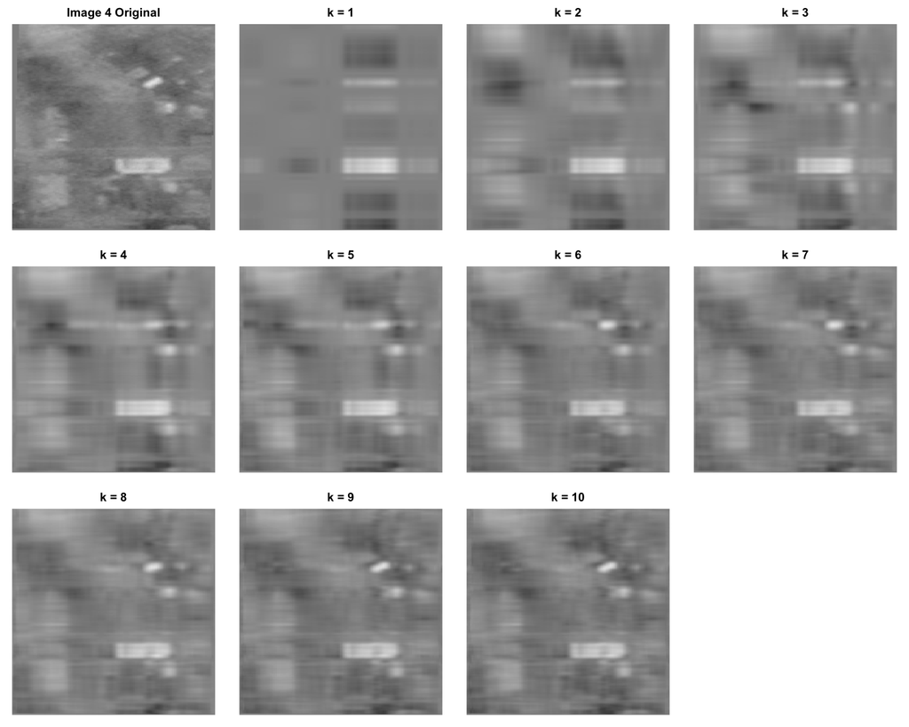

Image 4 also has a lot of variation and texture. The major bright and dark regions appear in the early approximations, but several components are needed before the overall scene starts to look close to the original.

## Approximation error

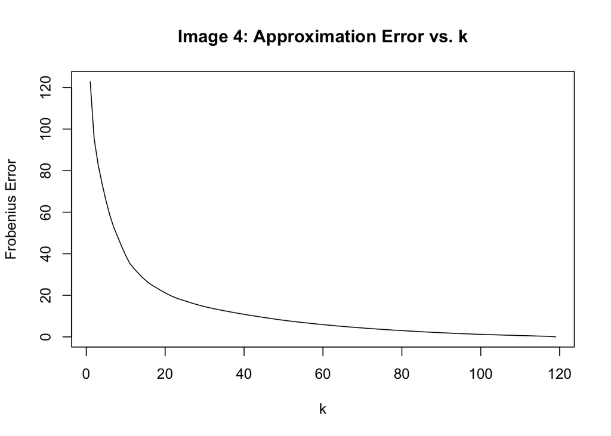

The error decreases quickly for the first several components and then starts to level off. This shows that the early components contain most of the main structure, while later components add finer detail.

## First eigenvector and first PC score

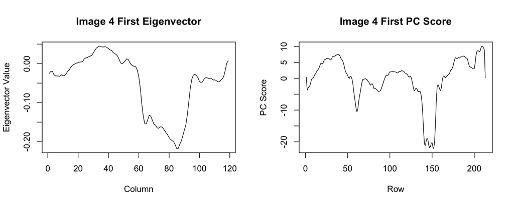

The first eigenvector captures the main pattern of brightness across the columns of Image 4. The first PC score shows how strongly this pattern appears at each row. These two pieces make up the strongest rank-1 pattern in the image, while the later components are needed to recreate smaller visual details.

## My choice of k

I would use about **k = 20** for Image 4. The main parts of the image are visible and the reconstruction is much closer to the original. Going higher continues to improve the image, but the extra detail comes with less compression.

# Conclusion

PCA works well when an image has a simple structure that can be represented with only a few components. Image 2 is the clearest example because two components are enough to reproduce almost the entire image. The two more detailed photographs need larger values of $k$, which shows the tradeoff between compression and image quality.

# Website build time

```
## [1] "2026-09-25 18:00:16 CDT"
```